# Projet Mixture model : JAFFE

#Binome: - Wacim BELAHCEL - Imad Oualid KACIMI

```r
library(R.matlab)
library(Factoshiny)
library(NbClust)
library(Rmixmod)
library(mclust)
library(clusterSim)
library(aricode)
library(h2o)
library(Rtsne)
library(tidyverse)
```

# Q1 : Introduction table de donnée

JAFFE est un dataset Contenant des images d’expressions facials de femme japonaises, avec 676 variables, le dataset est repartie en 10 classes.

```r
jaffe = readMat(con="C:\\Users\\GIGABYTE\\Downloads\\DATA_MATLAB - Projet-master-MLDS\\DATA_MATLAB - Projet-master-MLDS\\jaffe.mat")
```

```r
y_data = as.data.frame(jaffe$y)
x_data = as.data.frame(jaffe$X)
#x_test_data = as.data.frame(mnist$testX)
#y_test_data = as.data.frame(mnist$testY)
```

```r
x_data$y<-as.factor(t(y_data))

x_data <- x_data[!duplicated(x_data[,1:64]), ]
y_data <- as.data.frame(x_data$y)
```

# Question 2: ACP

Depuis le graph des individus, on peut remarquer que la plus part des classes sont parfaitement séparable entre elles, cependant il existe un chevauchement important entre certains clusters, notamment y_3 et y_10 ou y_1 et y_7. Lorsque l’on représente uniquement les modalité de la variable cible y, on peut confirmer notre précedente observation, on remarque aussi que les individu de la classe y_4 contribuent fortement à la creation de l’axe 2, la méme observation peut étre faite pour y_6 et y_3 par rapport à l’axe 1.

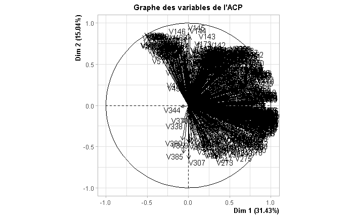

```r
res.PCA<-PCA(x_data,quali.sup=c(677),graph=FALSE)
plot.PCA(res.PCA,choix='var',title="Graphe des variables de l'ACP")
```

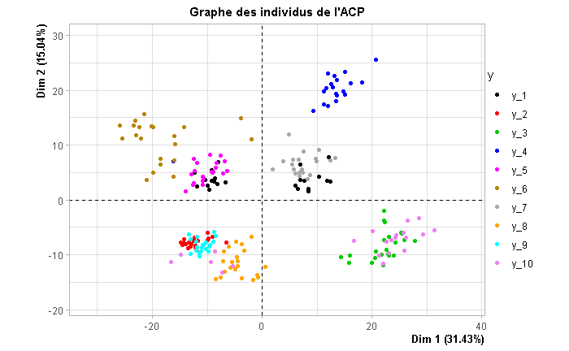

```r
plot.PCA(res.PCA,invisible=c('quali','ind.sup'),habillage=677,title="Graphe des individus de l'ACP",label ='none')
```

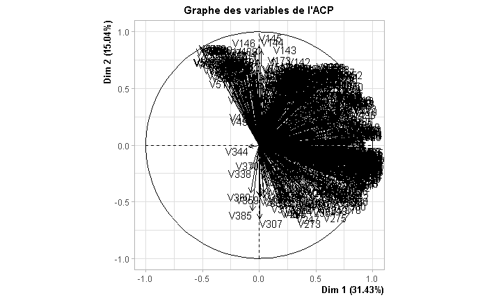

```r
res.PCA<-PCA(x_data,quali.sup=c(677),graph=FALSE)
plot.PCA(res.PCA,choix='var',title="Graphe des variables de l'ACP")
```

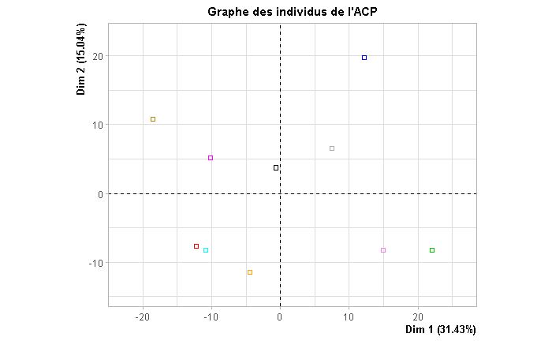

```r
plot.PCA(res.PCA,invisible=c('ind','ind.sup'),habillage=677,title="Graphe des individus de l'ACP",label =c('quali'))
```

# Q4: Clustering Kmean / CAH

La plus part des algorithme ne trouvent que 4 classes en tant que nombre optimal lorsque nous appliquons un clustering, ce qui est explicable si on compare cela à nos observations precedentes ou nous avions remarquer qu’il existe un chevauchement entre differentes classes dans une meme partition, nous remarquons aussi que l’algorithme CAH average retrouve bel et bien 7 classes. nous pouvons donc proposer 4 classes si nous nous basons uniquement sur ces rsultats la.

```r
res_cah_ward <-NbClust(x_data[,1:676], distance = "euclidean", min.nc=2, max.nc=10, method = "ward.D2",
index = "ch")
res_cah_average<-NbClust(x_data[,1:676], distance = "euclidean", min.nc=2, max.nc=10, method = "average",
index = "ch")
res_cah_complete <-NbClust(x_data[,1:676], distance = "euclidean", min.nc=2, max.nc=10, method = "complete",
index = "ch")
res_cah_single <-NbClust(x_data[,1:676], distance = "euclidean", min.nc=2, max.nc=10, method = "single",
index = "ch")
res_cah_kmeans <-NbClust(x_data[,1:676], distance = "euclidean", min.nc=2, max.nc=10, method = "kmeans",
index = "ch")
```

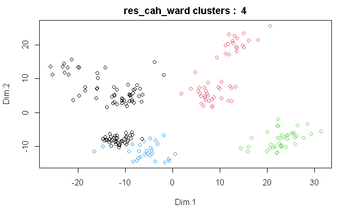

```r
plot(res.PCA$ind$coord,col=res_cah_ward$Best.partition, main = paste("res_cah_ward clusters : ",length(unique(res_cah_ward$Best.partition))))
```

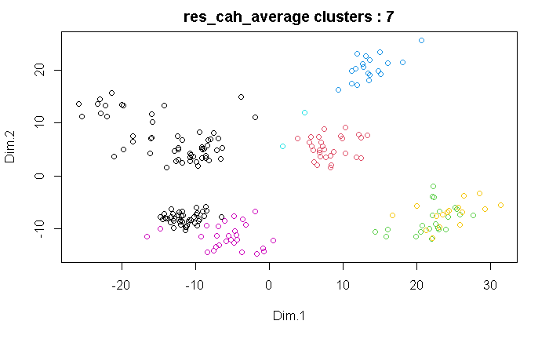

```r
plot(res.PCA$ind$coord,col=res_cah_average$Best.partition, main = paste("res_cah_average clusters :",length(unique(res_cah_average$Best.partition))))
```

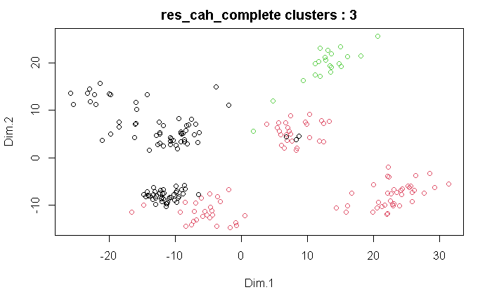

```r
plot(res.PCA$ind$coord,col=res_cah_complete$Best.partition,  main = paste("res_cah_complete clusters :",length(unique(res_cah_complete$Best.partition))))
```

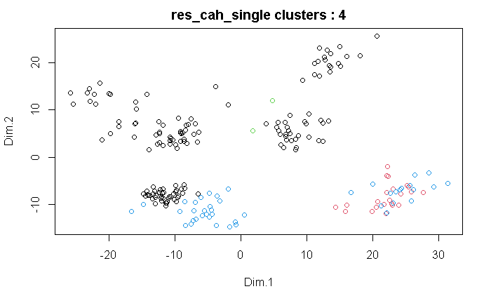

```r
plot(res.PCA$ind$coord,col=res_cah_single$Best.partition, main = paste("res_cah_single clusters :",length(unique(res_cah_single$Best.partition))))
```

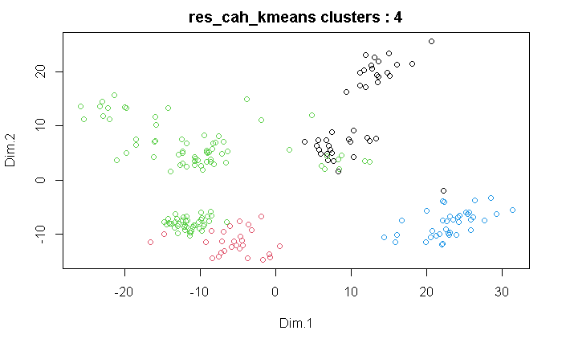

```r
plot(res.PCA$ind$coord,col=res_cah_kmeans$Best.partition, main = paste("res_cah_kmeans clusters :",length(unique(res_cah_kmeans$Best.partition))))
```

# Q5 : HCPC

En observant aussi le graph de l’inertie, on peut remarquer un coude à la 3 éme barre, on pourrait aussi aller j’usqu’à la 4 éme barre, il est donc possible de proposer 3 à 4 classes.

```r
res.PCA<-PCA(x_data,ncp=Inf, scale.unit=FALSE,quali.sup=c(677),graph=FALSE)
res.HCPC<-HCPC(res.PCA,nb.clust=3,consol=FALSE,graph=FALSE)
```

```
Chi-squared approximation may be incorrect
```

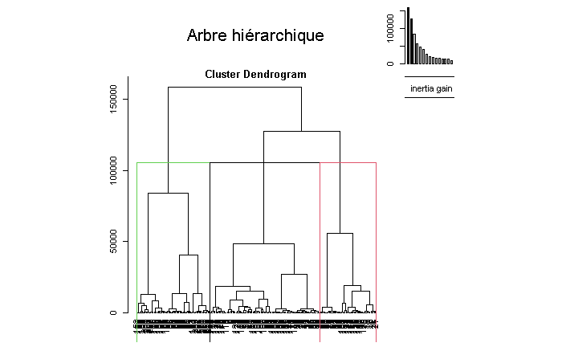

```r
plot.HCPC(res.HCPC,choice='tree',title='Arbre hiérarchique')
```

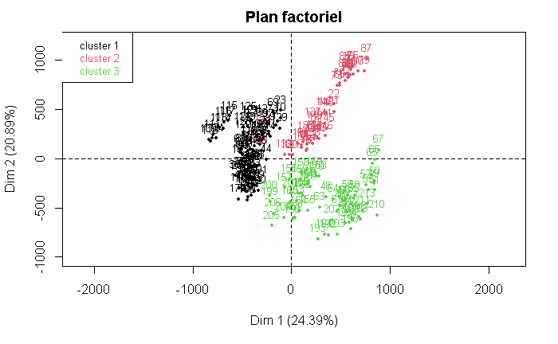

```r
plot.HCPC(res.HCPC,choice='map',draw.tree=FALSE,title='Plan factoriel')
```

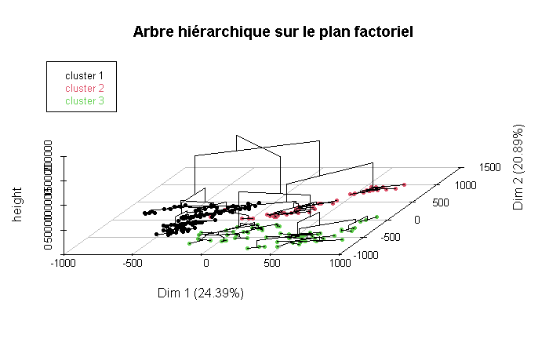

```r
plot.HCPC(res.HCPC,choice='3D.map',ind.names=FALSE,centers.plot=FALSE,angle=60,title='Arbre hiérarchique sur le plan factoriel')
```

# Q6 : comparaison avec HCPC

```r
table(as.vector(res.HCPC$data.clust[,"clust"]),as.vector(res_cah_ward$Best.partition))
```

```
     1  2  3  4
  1 98  0  0  0
  2  0 50  0  0
  3  0  0 38 27
```

```r
table(as.vector(res.HCPC$data.clust[,"clust"]),as.vector(res_cah_kmeans$Best.partition))
```

```
     1  2  3  4
  1  0  0 98  0
  2 40  0 10  0
  3  1 27  0 37
```

```r
table(as.vector(res.HCPC$data.clust[,"clust"]),as.vector(res_cah_complete$Best.partition))
```

```
     1  2  3
  1 98  0  0
  2  3 26 21
  3  0 65  0
```

```r
table(as.vector(res.HCPC$data.clust[,"clust"]),as.vector(res_cah_single$Best.partition))
```

```
     1  2  3  4
  1 98  0  0  0
  2 48  0  2  0
  3  0 22  0 43
```

```r
table(as.vector(res.HCPC$data.clust[,"clust"]),as.vector(res_cah_average$Best.partition))
```

```
     1  2  3  4  5  6  7
  1 98  0  0  0  0  0  0
  2  0 29  0 19  2  0  0
  3  0  0 22  0  0 27 16
```

# Q7 : MCLUST et RMIXMOD

```r
set.seed(1)
res.PCA<-PCA(x_data,ncp=15,quali.sup=c(677),graph=FALSE)

res.mclust=Mclust(res.PCA$ind$coord,G = 1:10)
```

```
fitting ...
```

```r
summary(res.mclust$BIC)
```

```
Best BIC values:
            VEV,10       VEI,10       VEV,8
BIC      -16818.14 -16872.89874 -16957.3662
BIC diff      0.00    -54.75606   -139.2235
```

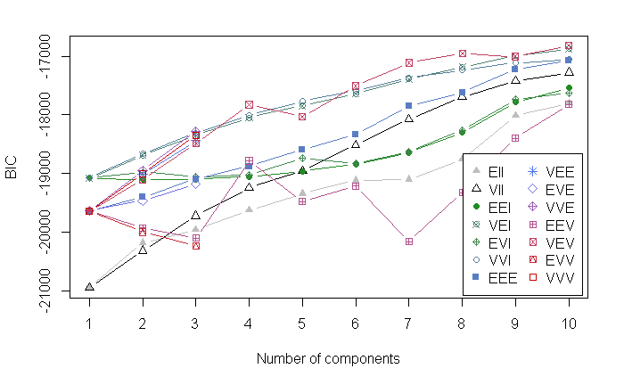

```r
plot(res.mclust,what="BIC")
```

```r
names(res.mclust)
```

```
 [1] "call"           "data"           "modelName"      "n"
 [5] "d"              "G"              "BIC"            "loglik"
 [9] "df"             "bic"            "icl"            "hypvol"
[13] "parameters"     "z"              "classification" "uncertainty"
```

```r
table(res.mclust$class,as.vector(y_data[,1]))
```

```
      1 10  2  3  4  5  6  7  8  9
  1  15  0  0  0  0  0  0  0  0  0
  2   8  9  0  3  7 21  0  5 12  0
  3   0  0 22  0  0  0  0  0  0  0
  4   0  0  0 19  0  0  0  0  0  0
  5   0  0  0  0 13  0  0  0  0  0
  6   0  0  0  0  0  0 21  0  0  0
  7   0  0  0  0  0  0  0 15  0  0
  8   0  0  0  0  0  0  0  0  9  0
  9   0  0  0  0  0  0  0  0  0 21
  10  0 13  0  0  0  0  0  0  0  0
```

```r
res.mclust$modelName
```

```
[1] "VEV"
```

```r
adjustedRandIndex(res.mclust$class,as.vector(y_data[,1]))
```

```
[1] 0.5297832
```

```r
set.seed(1)
res.mixmod = mixmodCluster(data=as.data.frame(res.PCA$ind$coord),nbCluster=1:10,models=mixmodGaussianModel(listModels = c( "Gaussian_pk_Lk_Dk_A_Dk", "Gaussian_p_Lk_Dk_A_Dk")))
#
#res.mixmod
summary(res.mixmod)
```

```
* Number of samples    =  213
* Problem dimension    =  15
*       Number of cluster =  10
*              Model Type =  Gaussian_p_Lk_Dk_A_Dk
*               Criterion =  BIC(16254.8184)
*              Parameters =  list by cluster
*                  Cluster  1 :
                         Proportion =  0.1000
                              Means =  -1.9453 2.5321 7.9940 7.8250 2.2913 0.3884 3.6971 -3.5994 -3.9958 -0.1660 -2.0836 1.6527 -0.2475 -2.7143 -0.3152
                          Variances = |   131.0282   -47.0643    19.9908    50.1520    45.9095    31.9229    -3.4489    16.0936    13.0876   -49.1934    37.6159     6.1311   -29.8151    -1.1864    -4.1661 |
                                      |   -47.0643    25.4647    -4.0845   -27.1946    -9.9909    -7.4266    -8.2682    -6.6938    -2.5660    15.7268   -20.2070    -1.3036    12.8107     0.6480     1.6364 |
                                      |    19.9908    -4.0845     9.3524     6.8999    11.3967     5.5218    -0.8259     1.0198     3.2619   -10.8494     2.6061     1.3948    -5.0844    -0.0228    -2.0203 |
                                      |    50.1520   -27.1946     6.8999    33.7640     6.0913     4.7817    17.0665     7.2210     4.5482   -16.7246    22.4088     2.9839   -14.7365    -2.2303    -2.5080 |
                                      |    45.9095    -9.9909    11.3967     6.0913    34.4745    15.2588   -18.4850     3.0207     4.9076   -23.4034     5.2253    -1.7691    -7.7034     3.0421    -1.8679 |
                                      |    31.9229    -7.4266     5.5218     4.7817    15.2588    21.5233   -10.6943     5.3892     1.0950   -12.4696     7.5023     6.7702    -8.8737    -1.4298     1.0971 |
                                      |    -3.4489    -8.2682    -0.8259    17.0665   -18.4850   -10.6943    27.8634     1.5652     1.4799     3.9668     7.7938     2.2821    -2.6161    -4.3496    -0.9801 |
                                      |    16.0936    -6.6938     1.0198     7.2210     3.0207     5.3892     1.5652     3.2137     1.6018    -4.9673     6.2177     2.4026    -4.4742    -1.3099     0.2927 |
                                      |    13.0876    -2.5660     3.2619     4.5482     4.9076     1.0950     1.4799     1.6018     4.1039    -5.7664     1.8451     0.5009    -2.5178    -0.8998    -0.6984 |
                                      |   -49.1934    15.7268   -10.8494   -16.7246   -23.4034   -12.4696     3.9668    -4.9673    -5.7664    22.2928   -11.5129    -1.2081    10.6145    -0.1473     2.3322 |
                                      |    37.6159   -20.2070     2.6061    22.4088     5.2253     7.5023     7.7938     6.2177     1.8451   -11.5129    17.5437     3.0630   -10.9312    -1.4578    -0.5614 |
                                      |     6.1311    -1.3036     1.3948     2.9839    -1.7691     6.7702     2.2821     2.4026     0.5009    -1.2081     3.0630     5.6090    -3.1360    -2.6495     0.9491 |
                                      |   -29.8151    12.8107    -5.0844   -14.7365    -7.7034    -8.8737    -2.6161    -4.4742    -2.5178    10.6145   -10.9312    -3.1360    10.1905     0.9257     0.7699 |
                                      |    -1.1864     0.6480    -0.0228    -2.2303     3.0421    -1.4298    -4.3496    -1.3099    -0.8998    -0.1473    -1.4578    -2.6495     0.9257     2.0606    -0.5259 |
                                      |    -4.1661     1.6364    -2.0203    -2.5080    -1.8679     1.0971    -0.9801     0.2927    -0.6984     2.3322    -0.5614     0.9491     0.7699    -0.5259     1.1808 |
*                  Cluster  2 :
                         Proportion =  0.1000
```

[output cut: 161 more lines]

```r
predictions= mixmodPredict(as.data.frame(res.PCA$ind$coord), classificationRule=res.mixmod["bestResult"])
```

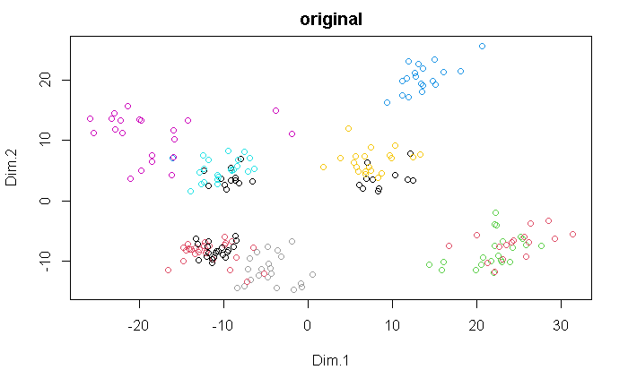

```r
pred.rmix = as.vector(predictions["partition"])
pred.mclust = as.vector(res.mclust$class)
true_values = as.vector(y_data[,1])

plot(res.PCA$ind$coord,col=true_values, main = "original")
```

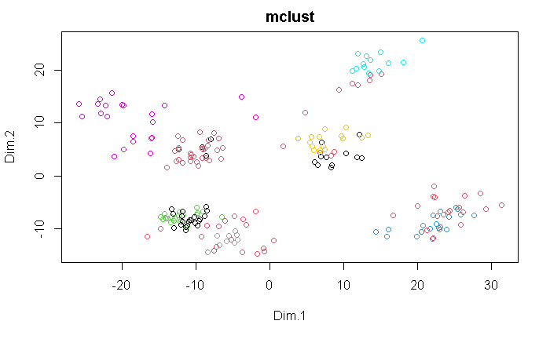

```r
plot(res.PCA$ind$coord,col=pred.mclust, main = "mclust")
```

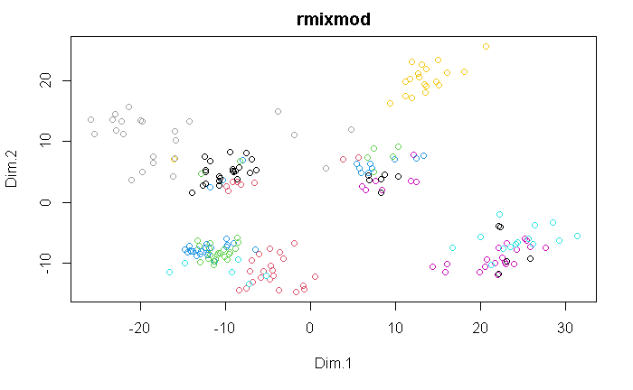

```r
plot(res.PCA$ind$coord,col=pred.rmix, main = "rmixmod")
```

# Q8 : comparer les partitions de mclust et rmixmod

Les resultats des deux packages sont plus ou moins similaire sur la plus part des clusters (exemple cluster 6 de mclust plus ou moins égale au cluster 8 de rmixmod), nous remarquons cependant un desaccord pour le cluster 2 de mclust avec l’nsembles des clusters de rmixmod

```r
table(pred.rmix,pred.mclust)
```

```
         pred.mclust
pred.rmix  1  2  3  4  5  6  7  8  9 10
       1   0 20  0  0  0  0  0  0  0  0
       2   0 10  0  0  0  0  0  9  0  0
       3   0  2  0  0  0  0  5  0 21  0
       4   2  2 22  0  0  0  8  0  0  0
       5   0  7  0  0  0  0  0  0  0 13
       6   7  0  0 19  0  0  0  0  0  0
       7   0  7  0  0 13  0  0  0  0  0
       8   0  2  0  0  0 21  0  0  0  0
       9   6  7  0  0  0  0  0  0  0  0
       10  0  8  0  0  0  0  2  0  0  0
```

# Q9: MclustDR

MclustDR est une methode de reduction de la dimension linéaire utilisé afin de visualiser le resultat de clustering ou de classification obtenue par des mélanges gaussiens.

```r
res.mclustdr = MclustDR(res.mclust)
summary(res.mclustdr)
```

```
-----------------------------------------------------------------
Dimension reduction for model-based clustering and classification
-----------------------------------------------------------------

Mixture model type: Mclust (VEV, 10)

Clusters  n
      1  15
      2  65
      3  22
      4  19
      5  13
      6  21
      7  15
      8   9
      9  21
      10 13

Estimated basis vectors:
            Dir1      Dir2      Dir3       Dir4      Dir5      Dir6      Dir7
Dim.1  -0.119292  0.059604 -0.029848  0.0832932 -0.022535  0.034336 -0.178489
Dim.2  -0.089457 -0.185887  0.029273  0.0567562 -0.097505  0.077984 -0.077097
Dim.3  -0.266692 -0.298451 -0.022117  0.0085873  0.124635 -0.082631  0.251150
Dim.4  -0.150175 -0.011960 -0.174193 -0.1517471  0.089792 -0.119130 -0.224102
Dim.5  -0.370211  0.166165  0.086111 -0.1919421 -0.073707 -0.096161  0.172668
Dim.6  -0.010280  0.246131 -0.236091 -0.1945797 -0.011240  0.084995  0.152800
Dim.7   0.029076 -0.107841 -0.271019 -0.0134787 -0.050622 -0.359356 -0.059876
Dim.8  -0.216676  0.231229 -0.096263  0.0416526 -0.200408  0.192812  0.706046
Dim.9  -0.221521  0.125003  0.278832  0.4345172 -0.121664 -0.328152  0.127148
Dim.10  0.539598 -0.416324 -0.348506 -0.0079383 -0.321747  0.068456  0.312664
Dim.11 -0.029028  0.353070 -0.073224  0.2101036  0.541677  0.362419  0.267830
Dim.12 -0.384189  0.022464 -0.362151 -0.2695108 -0.229278  0.397697 -0.180947
Dim.13  0.012350 -0.320506  0.660180 -0.7224659  0.037530  0.278262 -0.259936
Dim.14  0.280661  0.549336  0.217677 -0.2495605 -0.257105 -0.548206  0.082872
Dim.15 -0.362670  0.027939  0.051079  0.0153359 -0.621520  0.095375 -0.028588
            Dir8       Dir9     Dir10     Dir11     Dir12      Dir13     Dir14
Dim.1   0.059846 -0.0142560 -0.105912  0.048514 -0.051997 -0.0169676 -0.067402
Dim.2  -0.282745  0.0016479  0.169855  0.079827 -0.078088 -0.0016741 -0.017813
Dim.3   0.106552  0.0473581 -0.066039  0.141185  0.079353  0.0132081 -0.106311
Dim.4  -0.056408  0.1969826  0.128708 -0.263559 -0.054103 -0.0229517 -0.111476
```

[output cut: 19 more lines]

```
Dim.8  -0.1117573
Dim.9  -0.1945487
Dim.10 -0.2150293
Dim.11  0.0668609
Dim.12 -0.2632626
Dim.13 -0.2156432
Dim.14 -0.1905148
Dim.15  0.8614606

              Dir1   Dir2   Dir3    Dir4    Dir5    Dir6     Dir7     Dir8
Eigenvalues 63.686 22.073 13.145  5.7086  3.0251  1.9214  0.94156  0.90385
Cum. %      54.832 73.836 85.153 90.0683 92.6728 94.3271 95.13774 95.91594
                Dir9    Dir10    Dir11    Dir12    Dir13    Dir14     Dir15
Eigenvalues  0.87371  0.81113  0.75123  0.72807  0.61421  0.51291   0.45226
Cum. %      96.66818 97.36654 98.01334 98.64019 99.16901 99.61062 100.00000
```

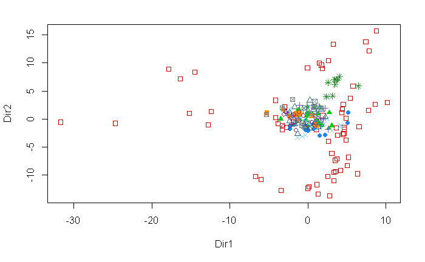

```r
plot(res.mclustdr, what="scatterplot")
```

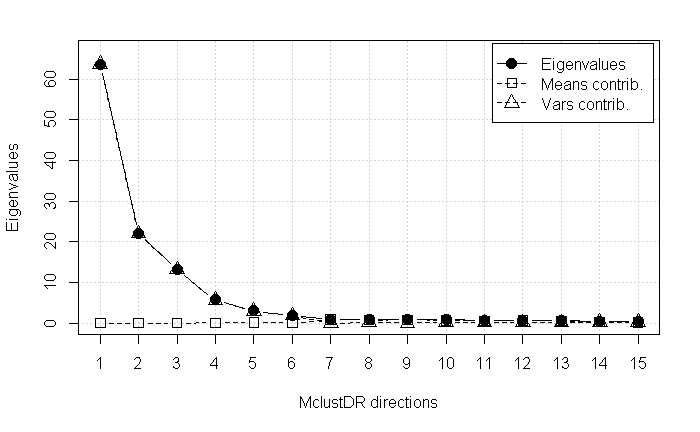

```r
plot(res.mclustdr, what="evalues")
```

# Q10: Comparaison des different algorithmes

```r
pred.rmix = as.vector(predictions["partition"])
pred.mclust = as.vector(res.mclust$class)
true_values = as.vector(y_data[,1])


print(paste("Rmixmod taux de mal classé : ", 1- comparing.Partitions(pred.rmix,true_values)))
```

```
[1] "Rmixmod taux de mal classé :  0.301093152371925"
```

```r
print(paste("Mclust taux de mal classé : ", 1-comparing.Partitions(pred.mclust,true_values)))
```

```
[1] "Mclust taux de mal classé :  0.274163228076272"
```

```r
print(paste("cah ward taux de mal classé : ", 1-comparing.Partitions(res_cah_ward$Best.partition,true_values)))
```

```
[1] "cah ward taux de mal classé :  0.598118595809251"
```

```r
print(paste("cah average taux de mal classé : ", 1-comparing.Partitions(res_cah_average$Best.partition,true_values)))
```

```
[1] "cah average taux de mal classé :  0.428080741178394"
```

```r
print(paste("cah complete de mal classé : ", 1-comparing.Partitions(res_cah_complete$Best.partition,true_values)))
```

```
[1] "cah complete de mal classé :  0.683793231394145"
```

```r
print(paste("cah singe  taux de mal classé : ", 1-comparing.Partitions(res_cah_single$Best.partition,true_values)))
```

```
[1] "cah singe  taux de mal classé :  0.659345560460565"
```

```r
print(paste("kmeans  taux de mal classé : ", 1-comparing.Partitions(res_cah_kmeans$Best.partition,true_values)))
```

```
[1] "kmeans  taux de mal classé :  0.602574700135676"
```

```r
print("")
```

```
[1] ""
```

```r
print("")
```

```
[1] ""
```

```r
print(paste("Rmixmod ARI : ",adjustedRandIndex(pred.rmix,true_values)))
```

```
[1] "Rmixmod ARI :  0.651603027922501"
```

```r
(paste("Mclust ARI : ",adjustedRandIndex(pred.mclust,true_values)))
```

```
[1] "Mclust ARI :  0.529783238072588"
```

```r
print(paste("cah_ward ARI : ",adjustedRandIndex(res_cah_ward$Best.partition,true_values)))
```

```
[1] "cah_ward ARI :  0.317091569756123"
```

```r
(paste("cah_average ARI : ",adjustedRandIndex(res_cah_average$Best.partition,true_values)))
```

```
[1] "cah_average ARI :  0.370442990720727"
```

```r
(paste("cah_complete ARI : ",adjustedRandIndex(res_cah_complete$Best.partition,true_values)))
```

```
[1] "cah_complete ARI :  0.213145949340495"
```

```r
(paste("cah_single ARI : ",adjustedRandIndex(res_cah_single$Best.partition,true_values)))
```

```
[1] "cah_single ARI :  0.172832528049371"
```

```r
(paste("kmeans ARI : ",adjustedRandIndex(res_cah_kmeans$Best.partition,true_values)))
```

```
[1] "kmeans ARI :  0.269825037299723"
```

```r
print("")
```

```
[1] ""
```

```r
print("")
```

```
[1] ""
```

```r
print(paste("Rmixmod NMI : ",NMI(pred.rmix,true_values)))
```

```
[1] "Rmixmod NMI :  0.766256561740617"
```

```r
(paste("Mclust NMI : ",NMI(pred.mclust,true_values)))
```

```
[1] "Mclust NMI :  0.762970341494276"
```

```r
print(paste("cah_ward NMI : ",NMI(res_cah_ward$Best.partition,true_values)))
```

```
[1] "cah_ward NMI :  0.483476254086637"
```

```r
(paste("cah_average NMI : ",NMI(res_cah_average$Best.partition,true_values)))
```

```
[1] "cah_average NMI :  0.605821721441088"
```

```r
(paste("cah_complete NMI : ",NMI(res_cah_complete$Best.partition,true_values)))
```

```
[1] "cah_complete NMI :  0.340435413218146"
```

```r
(paste("cah_single NMI : ",NMI(res_cah_single$Best.partition,true_values)))
```

```
[1] "cah_single NMI :  0.360473732545996"
```

```r
(paste("kmeans NMI : ",NMI(res_cah_kmeans$Best.partition,true_values)))
```

```
[1] "kmeans NMI :  0.440704001275172"
```

# Q11: TSNE

```r
tsne_res <- Rtsne(x_data[,1:676], dims = 2, perplexity=30, verbose=TRUE, max_iter = 2500)
```

[output not shown]

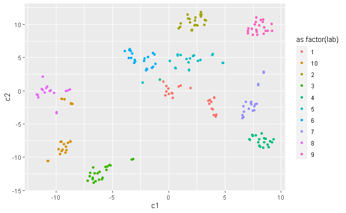

```r
tnse_df = as.data.frame(tsne_res$Y)
tnse_df = cbind(tnse_df,true_values, pred.rmix, pred.mclust)
names(tnse_df) = c("c1", "c2", "lab", "rmix", "mclust")
ggplot(tnse_df, aes(c1, y=c2, color=as.factor(lab)) ) + geom_point()
```

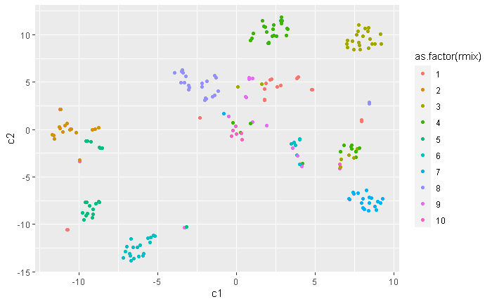

```r
ggplot(tnse_df, aes(c1, y=c2, color=as.factor(rmix)) ) + geom_point()
```

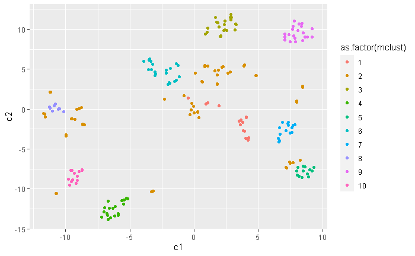

```r
ggplot(tnse_df, aes(c1, y=c2, color=as.factor(mclust))) + geom_point()
```

# Q12 : Reduction par autoencoder

On remarque que mclust obtient de meilleurs resultats de rmixmod. De maniére plus general la methode de reduction de dimension à l’aide d’auto encoder semble donner de meilleurs résultats et extraire plus d’informations (en particulier des relations non lineaire) que PCA.

```r
h2o.init()
```

[output not shown]

```
Your H2O cluster version is too old (3 months and 20 days)!
Please download and install the latest version from http://h2o.ai/download/
```

```r
ae_model <- h2o.deeplearning(x=c(1:676),
                                  model_id="ae_model",
                                  training_frame=as.h2o(x_data[,1:676]),
                                  activation="Tanh",
                                  ignore_const_cols=FALSE,
                                  autoencoder=TRUE,
                                  hidden=c(32, 16, 8, 16,32),
                                  epochs=50,
                                  reproducible=T,
                                  seed=1)
```

```r
features <- h2o.deepfeatures(ae_model, as.h2o(x_data[,1:676]), layer=3)
```

```r
set.seed(1)
res.mclust=Mclust(features, G = 1:10)
```

```
fitting ...
```

```r
summary(res.mclust$BIC)
```

```
Best BIC values:
            VEV,10     VEV,9    VVE,10
BIC      -341.9834 -446.8424 -509.4946
BIC diff    0.0000 -104.8590 -167.5112
```

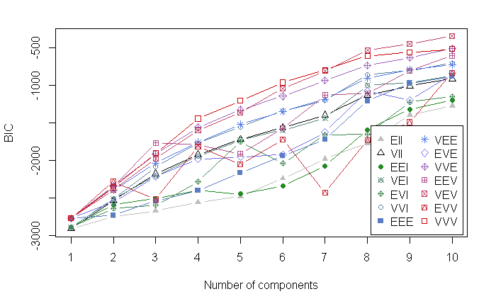

```r
plot(res.mclust,what="BIC")
```

```r
names(res.mclust)
```

```
 [1] "call"           "data"           "modelName"      "n"              "d"              "G"
 [7] "BIC"            "loglik"         "df"             "bic"            "icl"            "hypvol"
[13] "parameters"     "z"              "classification" "uncertainty"
```

```r
table(res.mclust$class,as.vector(y_data[,1]))
```

```
      1 10  2  3  4  5  6  7  8  9
  1  23  3  0  3  1  6  0  5  3  0
  2   0  0 22  0  0  0  0  0  0  0
  3   0  0  0 19  0  0  0  0  0  0
  4   0  0  0  0 19  0  0  0  0  0
  5   0  0  0  0  0 15  0  0  0  0
  6   0  0  0  0  0  0 21  0  0  0
  7   0  0  0  0  0  0  0 15  0  0
  8   0  6  0  0  0  0  0  0 18  0
  9   0  0  0  0  0  0  0  0  0 21
  10  0 13  0  0  0  0  0  0  0  0
```

```r
res.mclust$modelName
```

```
[1] "VEV"
```

```r
adjustedRandIndex(res.mclust$class,as.vector(y_data[,1]))
```

```
[1] 0.7142348
```

```r
res.mixmod = mixmodCluster(data=as.data.frame(features),nbCluster=1:10,models=mixmodGaussianModel(listModels = c("Gaussian_p_Lk_Ck", "Gaussian_pk_Lk_Ck")))
```

```r
predictions= mixmodPredict(as.data.frame(features), classificationRule=res.mixmod["bestResult"])
```

```r
pred.rmix = as.vector(predictions["partition"])
pred.mclust = as.vector(res.mclust$class)
true_values = as.vector(y_data[,1])

print(paste("Rmixmod taux de bien classé : ", comparing.Partitions(pred.rmix,true_values)))
```

```
[1] "Rmixmod taux de bien classé :  0.701369377904704"
```

```r
print(paste("Mclust taux de bien classé : ", comparing.Partitions(pred.mclust,true_values)))
```

```
[1] "Mclust taux de bien classé :  0.814155844155844"
```

```r
print(paste("Rmixmod ARI : ",adjustedRandIndex(pred.rmix,true_values)))
```

```
[1] "Rmixmod ARI :  0.650678895124666"
```

```r
(paste("Mclust ARI : ",adjustedRandIndex(pred.mclust,true_values)))
```

```
[1] "Mclust ARI :  0.714234824261793"
```

```r
print(paste("Rmixmod NMI : ",NMI(pred.rmix,true_values)))
```

```
[1] "Rmixmod NMI :  0.802265423062544"
```

```r
(paste("Mclust NMI : ",NMI(pred.mclust,true_values)))
```

```
[1] "Mclust NMI :  0.838455880184759"
```

[output not shown]